# Dataviz et packages R

Avril 2019

Pourquoi faire le choix de réaliser ses graphiques sous R ?

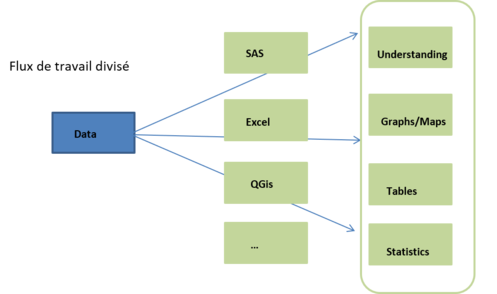

[figure not shown]

## **Visualiser ses données avec R**

- Les 4 systèmes graphiques en `R`
- Quelle stratégie adopter pour représenter mes données ?

## Ce que nous n'aborderons pas

- Cartographie
- Construction de graphiques animés
- Construction d'applications

Comment être efficace - construire mon graphique

## Comment être efficace - construire mon graphique

- Logiques de sythaxe des différents packages

## Avoir les bons réflexes

Les 4 systèmes graphiques sous `R`

## Les 4 systèmes graphiques

- *`Base graphics` :* le plus simple à apprendre
- *`Grid graphics` :* ensemble de modules puissants pour construire d'autres outils
- *`Lattice graphics` :* système à caractère général basé sur `Grid`
- *`ggplot2` :* basésur *"grammar of graphics"*

`Base graphics`

## Le plus simple à manipuler

### En phase d'exploration

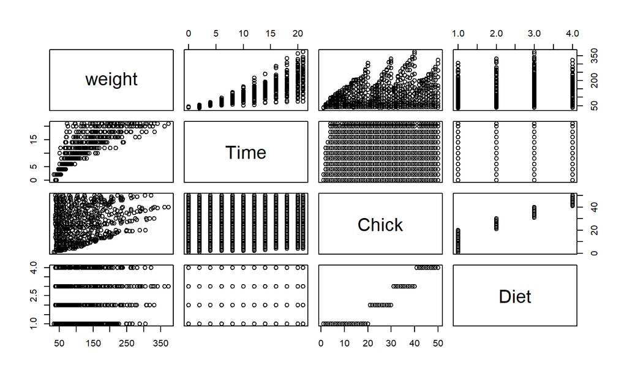

```r
plot(ChickWeight)
```

## Le plus simple à manipuler

### En phase d'exploration

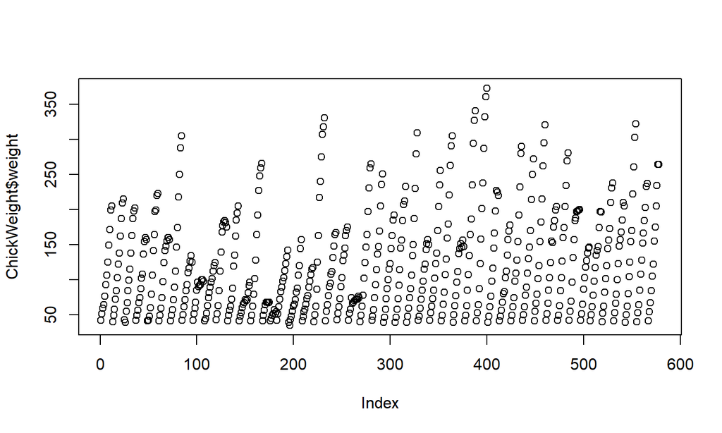

```r
plot(ChickWeight$weight)
```

## `Sunflowerplot`

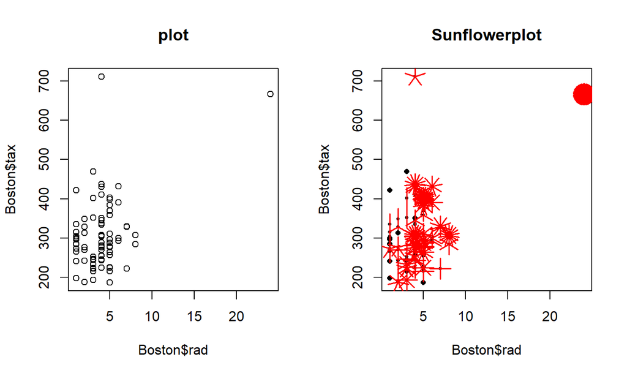

## Autres graphiques de base

- `boxplot`
- `mosaic plot`

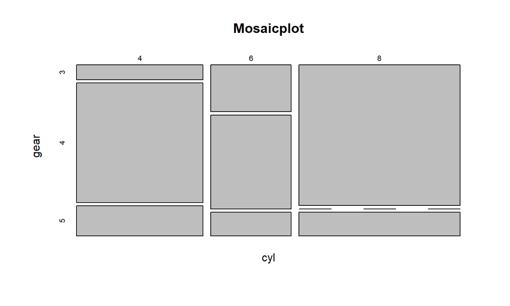

## Logique de construction

Les graphiques `R` de base peuvent être construits gràce à deux types de fonctions :

- `fonctions de haut niveau`
  - exemple :`plot()`
- `fonctions de bas niveau`
  - pour ajouter des caractéristiques au graphique
  - `lines()`
  - `text()`
  - `points()`

## La fonction `par()`

## Des graphiques avancés

`bagplot()` : [exemples](https://datavizproject.com/data-type/bagplot/)

## Ajouter des détails à mon graphique

`Grid graphics`

`Le package lattice`

## Le package `lattice`

### Basé sur "Trellis graphics" (Cleveland)

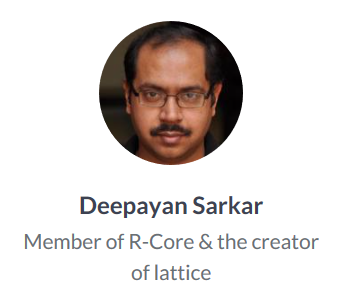

## Les packages basé sur chaque système

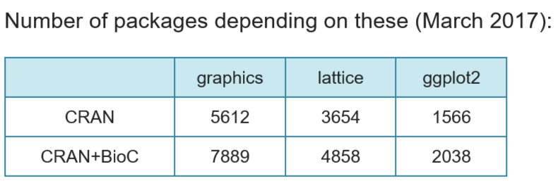

source : Datacamp

## Les arguments des fonctions de `lattice`

- Obligatoires
  - `~ x` : premier argument
  - `data` : le dataset qui contient les variables
- Optionnels
  - certains sont communs à toutes les fonctions
  - certains sont spécifiques à certaines fonctions

## Le package `lattice`

### But le plus important du package

- Réaliser des packages conditionnels
  - efficace pour détecter les sources de variabilité d'un phénomène
  - Comparaison entre différent sous-groupe de données

## "trellis" object

Le package permet de créer des objets qui pourront être appelés.

```r
tplot <- densityplot(~rate.male + rate.female,
                     data = USCancerRates, outer = T)

class(tplot)
```

```
## [1] "trellis"
```

## "trellis" object

```r
tplot <- densityplot(~rate.male + rate.female | state,
                     data = USCancerRates, outer = T)
head(summary(tplot)[[2]])
##
## state        rate.male rate.female
##   Alabama           67          67
##   Alaska            20          20
##   Arizona           15          15
##   Arkansas          75          75
##   California        57          57
##   Colorado          56          56
```

## "trellis" object

Il faut voir cet objet comme un `array`

```r
tplot <- densityplot(~rate.male + rate.female | state,
                     data = USCancerRates, outer = T)
dim(tplot)
## [1] 49  2
```

## "trellis" object

On peut ensuite mettre à jour un argument grâce à la fonction `update()`

## Le package `ggplot2`

### Pourquoi il est intéressant de connaître la synthaxe de ce package ?

- basé sur *"the grammar of graphics"*
- écosystème riche : beaucoup de packages reprennent la logique de `ggplot2`
- un package du `tidyverse`

## *Grammar of graphics*

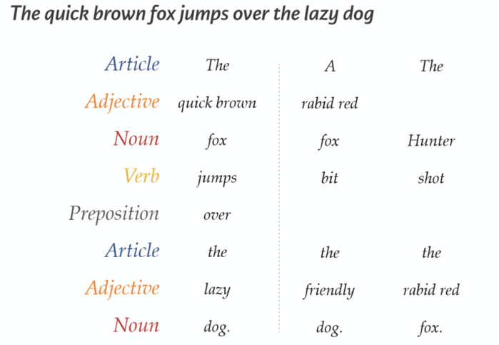

## Grammar of graphics

"The Grammar of Graphics"" de Leland Wilkinson a eu une influence importante sur la façon de penser les graphes  
2 principes

- Graphique = différentes couches d’éléments grammaticaux
- Des graphiques signifiants respectant des règles mathématiques et esthétiques

## Le package `ggplot2`

- Le package ggplot2 permet la réalisation de graphiques directement à partir d’un fichier détail, d’un fichier détail pondéré, ou de données agrégées
  - On initialise un graphique
  - On y ajoute des calques

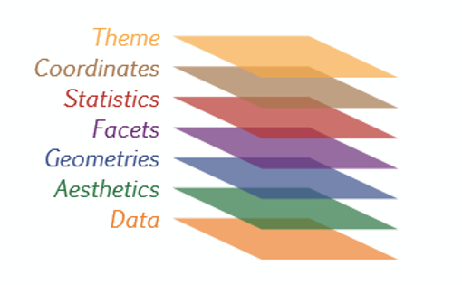

## Eléments essentiels de la grammaire

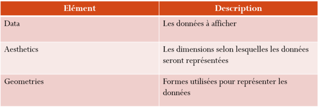

## Tous les éléments de la grammaire

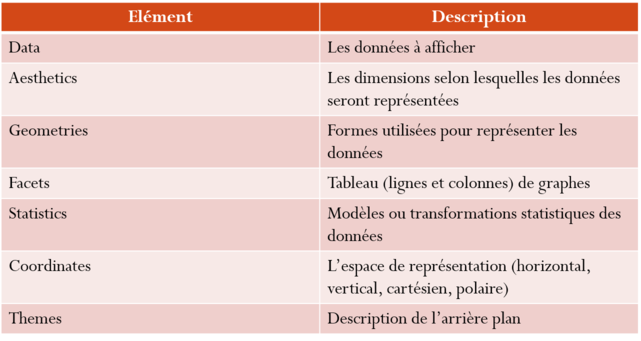

## …on peut y ajouter d'autres couches

- scales : l’échelle des axes (linéaire, logarithmique, à l’envers), les couleurs de remplissage
- ggtitle(" ") : ajoute un titre principal au graphique
- xlab(" ") : change le libellé des abscisses
- ylab(" ") : change le libellé des ordonnées
- labs( title = " ", x = " ", y = " ") : modifie titre principal, libellé des abscisses, libellé des ordonnées en une seule fonction
- etc.

## Comment je construis mon graphique avec `ggplot2` ?

1. J'initialise mon graphique
   - Deux fonctions pour le faire : `qplot()` et `ggplot()`
2. Chaque élément s'ajoute à un autre par le symbole +

## Comment je construis mon graphique avec `ggplot2` ?

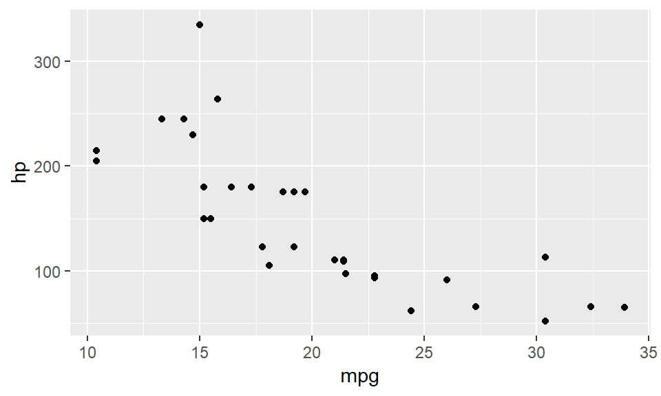

```r
library(ggplot2)
ggplot(data = mtcars)+
  geom_point(mapping = aes(x = mpg, y = hp))
```

## Une solution clique-bouton

### Idéale lors des phases exploratoires

Le package `esquisse`

```r
install.packages("esquisse")
library(esquisse)
```

[Site GitHub DreamRs](https://github.com/dreamRs/esquisse)

https://www.dreamrs.fr/

## Un package *helper* : `corrplot`

```r
library(corrplot)
```

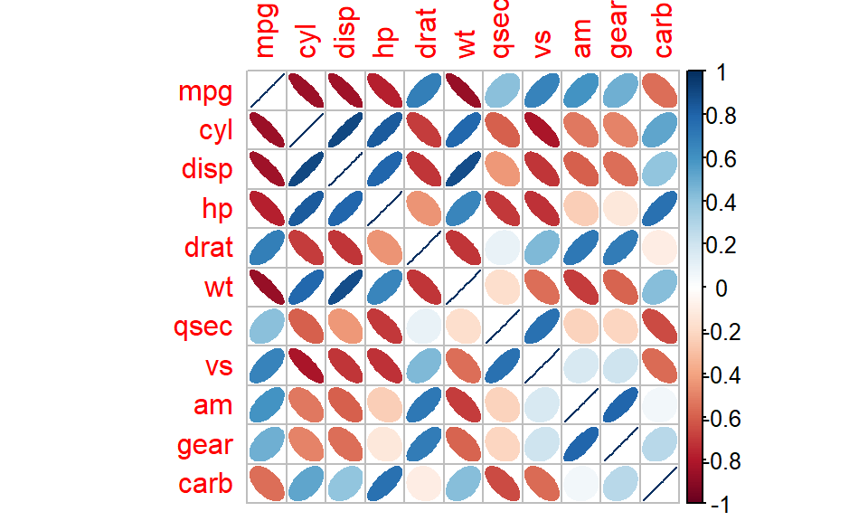

```r
correlation <- cor(mtcars)
# Fonction du package corrplot
corrplot(correlation,method = "ellipse")
```

## Des graphiques interactifs : une introduction

## Les différents types de graphiques

- statiques
- interactifs
- dynamiques / animés

## Exemples de dataviz

[Exemples de datavisualisation](https://uxplanet.org/functional-visualization-vs-artistic-dashboarding-8764cc117aa9)

[Exemples originaux de dataviz et musique](https://towardsdatascience.com/data-visualization-in-music-11fcd702c893)